# Introduction to dnapath

Tyler Grimes

2022-05-08

This is a brief introduction to the `dnapath` package. This package integrates known pathway information into the differential network analysis of gene expression data. It allows for any network inference method to be used, and provides wrapper functions for several popular methods; these all start with `run_` for ease of searching. Various helper function such as `summary()` and `plot()` are implemented for summarizing and visualizing the differential network results. This package is a companion to the paper:

> Grimes, T., Potter, S. S., & Datta, S. (2019). Integrating gene regulatory pathways into differential network analysis of gene expression data. *Scientific reports*, 9(1), 1-12.

# 1 Installation

You can install `dnapath` from CRAN:

```r
install.packages("dnapath")
```

# 2 Data

These are the two primary inputs to the `dnapath()` method – a gene expression dataset and a list of pathways – and are used to demonstrate the package usage in this vignette.

> **Note:** the `dnapath` package is not limited to cancer data. The analysis demonstrated in this introduction can be applied to any gene expression datasets from any species.

# 3 Overview of Functions

The main function of the package is `dnapath()`, which performs the differential network analysis on a gene expression dataset over a user-specified list of pathways. The output of this function is a `dnapath_list` object (or `dnapath` object if only one pathway is considered). An overview of its **arguments** is shown here:

- `dnapath()`: The main function for running the differential network analysis.
  - **x** - The gene expression data to be analyzed. Either (1) a list of two matrices or data frames that contain the gene expression profile from two populations (groups), or (2) a single matrix or data frame that contains the expression profiles for both groups. Rows should correspond to samples and columns to individual genes.
  - **pathway_list** - A single vector or list of vectors containing gene names to indicate pathway membership. The vectors are used to subset the columns of the matrices in ‘x’.
  - **groups** - If `x` is a single matrix, `groups` must be specified to label each row. `groups` is a vector of length equal to the number of rows in `x`, and it should contain two unique elements (the two group names).
  - **network_inference** - A function used to infer the pathway network. It should take in an n by p matrix and return a p by p matrix of association scores. Built-in options are available, all being with `run_`. The default is `run_pcor` which computes partial correlations.
  - **n_perm** - The number of random permutations to perform during permutation testing. If `n_perm == 1`, the permutation tests are not performed. If `n_perm` is larger than the number of possible permutations, `n_perm` will be set to this value with a warning message.
  - **lp** - The lp value used to compute differential connectivity scores.
  - **seed** - (Optional) Used to `set.seed` prior to permutation test for each pathway. This allows results for individual pathways to be easily reproduced.

An overview of the other methods available in the `dnapath` package is given in the following sections.

## 3.1 Summarizing and visualizing the results

The `dnapath_list` and `dnapath` objects obtained from running `dnapath()` can be summarized and visualized using various methdos.

- `filter_pathways()`: Removes any pathways from the results that were not significantly differentially connected (based on the permutation test p-values for the pathway-level connectivity).
- `subset()` : Subset the results based on pathways or genes of interest.
  - **x** - A `dnapath_list` object.
  - **pathways** - A set of pathways to subset on. This can be (1) a vector of character strings, corresponding to pathway names or regular expressions used to find pathways, (2) a vector of indices to select pathways, (3) a vector of negative indices indicating pathways to remove, or (4) a logical (boolean) vector that is the same length of current number of pathways in x.
  - **genes** - A set of gene names to index on; exact matching is used. Only pathways containing these genes are retained.
- `sort()` : Sorts the pathways in the results.
  - **x** - A `dnapath_list` object.
  - **decreasing** - If TRUE (the default), results are sorted in decreasing order.
  - **by** - Used to specify which feature to sort by. These include: `by = "mean_expr"`, the mean expression of each pathway across both groups; `by = "mean_expr1"` or `by = "mean_expr2"`, the mean expression of each pathway in group 1 or 2, respectively; `by = "dc_score"`, the differential connectivity score of the pathway; `by = "p_value"`, the p-value of the dc score; `by = "n_genes"`, the number of genes in each pathway; or `by = "n_dc"` the number of significantly differentially conncted genes in each pathway.
- `summary()` : Creates a summary table for a `dnapath_list` or `dnapath` object.
- `plot()` : Plot the differential network from a `dnapath` object.
- `plot_pair()` : Plot the expression values of two genes to visualize their marginal association.

## 3.2 Obtaining a list of Reactome pathways

The user may specify any list of gene sets to use in the analysis. However, for convenience `dnapath` provides a function for obtaining a list of Reactome pathways for a given species. This list may be useful for most analyses.

- `get_reactome_pathways()` : Connects to the Reactome database (using the `reactome.db` package) to obtain a list of pathways for a given species.
  - **species** - The species to obtain a pathway list for. For example, “Homo sapiens” or “Mus musculus”.
  - **overlap_limit** - A value betwen 0 and 1. This is used to combine pathways that have substantial overlap. The default value is 0.9, so any two pathways that contain 90% or more genes will be combined into a single pathway.
  - **min_size** - The minimum pathway size. Any Reactome pathways with fewer than `min_size` genes are omitted from the list.
  - **max_size** - The maximum pathway size. Any Reactome pathways with more than `max_size` genes are removed from the list.

## 3.3 Renaming entrezgene IDs to gene symbols

The Reactome pathways are based on entrezgene IDs, which are a unique identifier for individual genes. It is recommended to also annotate RNA-seq data using entrezgene IDs when obtaining gene expression counts. However, when summarizing and visualizing the differential network analysis results, it may be preferred to use gene symbols. The functions in this section are used to rename the genes in a `dnapath_list` or `dnapath` object, or a pathway list.

- `rename_genes()`: Used to rename the genes contained in the differential network analysis results. This is useful if the user wants to, for example, create tables or plots summarizing the data using gene symbols rather than Entrezgene IDs. Note: this function can also be used to rename the genes in a pathway list.
  - **x** - A `dnapath_list` or `dnapath` object, or a pathway list.
  - **gene_mat** - (Optional) A two column matrix or data frame. The first column should contain the current gene names, and the second column the new gene names. Any gene that are not in this matrix (that is, genes in the dnapath results but not in the left column of this matrix) will retain their current name.
  - **to** - (Optional) Setting `to = "symbol"` will rename entrezgene IDs to gene symbols; this will automatically call the `entrez_to_symbol` method (defined below) to obtain the **gene_mat** matrix. The **species** arugment must also be specified when to is used.
  - **species** - (Optional) Must be specified when setting to = “symbol”. This argument is passed into `entrez_to_symbol()`.
- `entrez_to_symbol()` : Maps entrezgene IDs to gene symbols using the `biomaRt` package. The Reactome pathways use entrezgene IDs, and many RNA-seq pipelines will use entrezgene IDs for annotation. However, gene symbols are more recognizable and may be preferred for summarizing and visualizing results. This method maps entrezgene IDs to gene symbols, and the resulting two column matrix can be used with the `rename_genes()` method to rename entrezgene IDs as gene symbols.
- `symbol_to_entrez()` : Maps gene symbols to entrezgene IDs using the `biomaRt` package. This can be useful for renaming gene expression datasets that contain gene symbols. Note, however, that gene symbols can be ambiguous and may map to multiple entrezgene IDs. It is recommended to use entrezgene IDs throughout the analysis and only rename with gene symbols when summarizing the results.
- `get_genes()` : This method extracts the genes in a `dnapath_list` or `dnapath` object, or from a pathway list. This is not meant to summarize the results of the differential network analysis, but rather to help when renaming the genes in the results; the output is a vector of gene names that can be used in `entrez_to_symbol` or `symbol_to_entrez`.

## 3.4 Network inference methods

There are also several network inference methods provided in this package. Many of these are available in other R packages, but the format of their inputs and outputs can vary. Wrapper functions have been created to standardize these aspects. The method names are all prefixed with `run_` (for easy searching) and can be used as the **network_inference** argument in `dnapath()`. The methods are listed here, and additional information/references can be found in the package documentation.

- `run_aracne`, `run_bc3net`, `run_c3net`, `run_corr`, `run_dwlasso`, `run_genie3`, `run_glasso`, `run_mrnet`, `run_pcor`, and `run_silencer`.
  - All methods take in an $n$ by $p$ matrix of gene expression counts ($n$ samples and $p$ genes) as its first argument. The output of each is a $p$ by $p$ matrix of association scores.

The default method used is `run_pcor`, which infers the gene-gene association network using partial correlations. It is important to note that different measures may be better suited for answering different research questions, however those details are beyond the scope of this vignette.

> **Note:** For more information on any method, use the `help()` or `?` command in R to open the documentation (for example `help(run_aracne)` or `?run_pcor`).

# 4 Real data analysis example

This example will analyze the `meso` data provided in the package. (The “Package data” vignette shows how these data were obtained.) First we load the data and take a look at it.

```r
data(meso)
str(meso)
```

```
## List of 2
##  $ gene_expression: num [1:32, 1:150] 10.18 10.01 7.88 10.2 9.31 ...
##   ..- attr(*, "dimnames")=List of 2
##   .. ..$ : chr [1:32] "TCGA.3H.AB3S" "TCGA.3U.A98E" "TCGA.3U.A98G" "TCGA.SC.AA5Z" ...
##   .. ..$ : chr [1:150] "84883" "207" "208" "10000" ...
##  $ groups         : chr [1:32] "stageii" "stageiv" "stageiv" "stageiv" ...
```

The data is a list containing (1) a gene expression data set of 32 samples and 150 genes and (2) a vector indicating which group each sample belongs to – stageii (group 1) or stage iv (group 2).

## 4.1 No pathway information

The differential network analysis compares the gene-gene association network between the two groups (stage ii vs stage iv). The `dnapath` package *enables* the use of known pathway information into the analysis, but a pathway list is not required. The `dnapath()` method can be run on the full gene expression dataset, without using pathways:

```r
# Run dnapath using the gene expression and group information from meso dataset.
results <- dnapath(meso$gene_expression,
                   pathway_list = NULL,
                   group_labels = meso$groups)
results
```

```
## Differential network analysis between stageii (group 1) and stageiv (group 2).
## Results for an unnamed pathway (out of 1 pathways analyzed) containing 150 genes.
## Pathway p-value = 0.475. The mean expression of genes in the pathway is 9.3 in group 1 and 9.4 in group 2.
## # A tibble: 150 × 6
##    pathway genes  dc_score p_value mean_expr1 mean_expr2
##    <chr>   <chr>     <dbl>   <dbl>      <dbl>      <dbl>
##  1 unnamed 246175   0.116  0.00990       9.34       9.34
##  2 unnamed 2475     0.165  0.0297       10.2       10.3
##  3 unnamed 1616     0.139  0.0297       10.9       10.7
##  4 unnamed 8793     0.149  0.0396        6.90       7.02
##  5 unnamed 9099     0.122  0.0396        8.91       9.29
##  6 unnamed 94241    0.131  0.0495       10.1       10.1
##  7 unnamed 5933     0.0466 0.0495        5.95       6.30
##  8 unnamed 29117    0.151  0.0594        9.95      10.0
##  9 unnamed 91875    0.0940 0.0594        7.24       7.43
## 10 unnamed 8797     0.0884 0.0594        6.43       6.27
## # … with 140 more rows
```

The `plot` function can be used to view the differential network. In this case, since all genes were analyzed together, the differential network will show all genes present in the gene expression dataset.

> The `alpha = 0.05` argument will remove any edges whose differential connectivity score p-value is above 0.05.

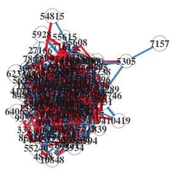

```r
plot(results, alpha = 0.05, only_dc = TRUE)
```

With 150 genes, the visualization of the differential network is not very useful; it is difficult to extract much information from this plot. One of the benefits of using known pathway information is that it breaks down the analysis into smaller gene sets, and the resulting differential networks are more manageable and informative. These advantages are illustrated in the next section.

## 4.2 Using a pathway list

The main feature of `dnapath` is that it incorporates known gene pathways into the differential network analysis. A pathway is nothing more than a set of genes that is thought to belong to a particular biological process. The `get_reactome_pathways` method can be used to obtain a list of pathways from the Reactome database.

In this section, we will use the `p53_pathways` data that accompanies the package. TP53 is a oncogene that is often mutated in many cancers, and the `p53_pathways` list contains 13 pathways related to P53 signaling.

> We refer the reader to the “Package data” vignette for details on how the `p53_pathways` list was created. That vignette illustrates how to use `get_reactome_pathways()`.

The difference compared to the previous section is that the `pathway_list` argument is now specified when running `dnapath()`. Additionally, we will use the `seed` argument (which is optional) so that each pathway result can be easily reproduced individually.

```r
data(meso) # Load the gene expression data
data(p53_pathways)

# Run the differential network analysis.
results <- dnapath(x = meso$gene_expression,
                   pathway_list = p53_pathways,
                   group_labels = meso$groups,
                   seed = 0)
```

[output not shown]

[output cut: 128 more lines]

[output not shown]

```r
results
```

```
## Differential network analysis results between stageii (group 1) and stageiv (group 2) over 13 out of 13 pathways analyzed.
## # A tibble: 13 × 7
##    pathway           dc_score p_value n_genes `n_dc (0.1)` mean_expr1 mean_expr2
##    <chr>                <dbl>   <dbl>   <int>        <int>      <dbl>      <dbl>
##  1 Regulation of TP…    1.77   0.158       37            8      10.1       10.2
##  2 Regulation of TP…    1.15   0.931       30            0      10.2       10.2
##  3 Regulation of TP…    0.880  0.158       14            5       7.70       7.60
##  4 TP53 Regulates T…    2.35   0.644       49            2       9.09       9.16
##  5 TP53 Regulates T…    1.30   0.941       14            0       7.76       7.94
##  6 TP53 Regulates T…    2.03   0.238       44            6       8.68       8.73
##  7 TP53 regulates t…    1.05   0.139       14            5       8.52       8.46
##  8 Regulation of TP…    1.28   0.0990      19            3      10.8       10.8
##  9 TP53 Regulates T…    1.55   0.653       18            0       9.37       9.35
## 10 TP53 Regulates T…    1.32   0.535       20            0       8.59       8.61
## 11 TP53 regulates t…    0.954  0.792       21            0       9.88       9.92
## 12 TP53 Regulates T…    0.906  0.822       12            0       8.15       8.16
## 13 TP53 Regulates T…    0.998  0.0792      12            3       7.91       7.91
```

The results can be filtered using the `filter_pathways` method to remove any pathways with differential connectivity p-values above some threshold. This is demonstrated in the following code, which uses a threshold of 0.1.

```r
results <- filter_pathways(results, alpha_pathway = 0.1)
results
```

```
## Differential network analysis results between stageii (group 1) and stageiv (group 2) over 2 out of 13 pathways analyzed.
## # A tibble: 2 × 7
##   pathway            dc_score p_value n_genes `n_dc (0.1)` mean_expr1 mean_expr2
##   <chr>                 <dbl>   <dbl>   <int>        <int>      <dbl>      <dbl>
## 1 Regulation of TP5…    1.28   0.0990      19            3      10.8       10.8
## 2 TP53 Regulates Tr…    0.998  0.0792      12            3       7.91       7.91
```

The pathways can also be easily sorted based on different values. For example, the follow code sorts the pathways so that the one with the highest number of differentially connected genes is listed first. **Note:** this method of ordering will tend to favor larger pathways, since there are more changes for that pathway to contain differentially connected genes just by chance.

```r
results <- sort(results, decreasing = TRUE, by = "n_dc")
results
```

```
## Differential network analysis results between stageii (group 1) and stageiv (group 2) over 2 out of 13 pathways analyzed.
## # A tibble: 2 × 7
##   pathway            dc_score p_value n_genes `n_dc (0.1)` mean_expr1 mean_expr2
##   <chr>                 <dbl>   <dbl>   <int>        <int>      <dbl>      <dbl>
## 1 Regulation of TP5…    1.28   0.0990      19            3      10.8       10.8
## 2 TP53 Regulates Tr…    0.998  0.0792      12            3       7.91       7.91
```

Pathways can be plotted one at a time by indexing the results list. The following code shows how to print out the first pathway.

> **Note:** The layout of the nodes is random when generating plots. For reproducible plots, the random number generator seed needs to be set prior to plotting.

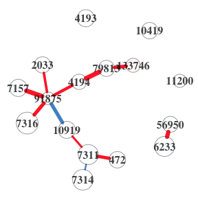

```r
# The plot layout is stochastic. Setting the RNG seed allows for reproducible plots.
set.seed(0)
plot(results[[1]], alpha = 0.05, only_dc = TRUE)
```

This plot uses entrezgene IDs, which are the identifiers used in the gene expression and pathway list data. At this point in the analysis it can be convenient to translate these IDs to the more recognizable gene symbols. The `rename_genes` method can be used to achieve this.

> **Note:** Internet connection is required to connect to biomaRt, which `rename_genes` uses to map entrezgene IDs to gene symbols. The `dir_save` argument can be set when running `rename_genes()` which will save the ID mapping obtained from biomaRt in the specified directory. This way, the mapping can be obtained once (using the internet connection) and accessed from memory in all future calls of `rename_genes()`. A temporary directory is used in this example.

```r
results <- rename_genes(results, to = "symbol", species = "human",
                        dir_save = tempdir())
```

```
## Connecting to biomaRt database...
```

```
##  - saving gene info to /var/folders/vb/115zgf4x28vf40dccy9mj5hw0000gn/T//RtmpGAJBIA/entrez_to_hsapiens.rds
```

```r
results[[1]] # Print the results for the first pathway.
```

```
## Differential network analysis between stageii (group 1) and stageiv (group 2).
## Results for the pathway "Regulation of TP53 Activity through Methylation" (out of 13 pathways analyzed) containing 16 genes.
## Pathway p-value = 0.099. The mean expression of genes in the pathway is 10.8 in group 1 and 10.8 in group 2.
## # A tibble: 16 × 6
##    pathway                          genes dc_score p_value mean_expr1 mean_expr2
##    <chr>                            <chr>    <dbl>   <dbl>      <dbl>      <dbl>
##  1 Regulation of TP53 Activity thr… TTC5     0.339  0.0297       7.24       7.43
##  2 Regulation of TP53 Activity thr… EHMT2    0.354  0.0396      11.0       10.9
##  3 Regulation of TP53 Activity thr… MDM4     0.223  0.0990       9.48       9.43
##  4 Regulation of TP53 Activity thr… ATM      0.215  0.139       10.2       10.4
##  5 Regulation of TP53 Activity thr… EHMT1    0.206  0.158       10.1       10.1
##  6 Regulation of TP53 Activity thr… UBA52    0.155  0.178       13.7       13.4
##  7 Regulation of TP53 Activity thr… CHEK2    0.212  0.208        7.76       7.72
##  8 Regulation of TP53 Activity thr… RPS2…    0.193  0.208       13.6       13.3
##  9 Regulation of TP53 Activity thr… EP300    0.136  0.267       10.0       10.2
## 10 Regulation of TP53 Activity thr… TP53     0.229  0.287       11.1       10.8
## 11 Regulation of TP53 Activity thr… SMYD2    0.186  0.287        9.93       9.86
## 12 Regulation of TP53 Activity thr… MDM2     0.211  0.327       11.0       11.1
## 13 Regulation of TP53 Activity thr… 7316     0.191  0.426       15.4       15.4
## 14 Regulation of TP53 Activity thr… JMY      0.168  0.436        8.11       8.49
## 15 Regulation of TP53 Activity thr… PRMT5    0.137  0.505       10.4       10.4
## 16 Regulation of TP53 Activity thr… UBB      0.139  0.535       14.2       14.1
```

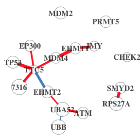

```r
set.seed(0) # Reset seed to use same layout as previous plot.
plot(results[[1]], alpha = 0.05, only_dc = TRUE)
```

The plot is useful for a quick overview of the findings; a detailed report of the differential connections can be obtained using the `summarize_edges()` function.

```r
# Summary table of the edges in pathway 1.
summarize_edges(results[[1]], alpha = 0.05)
```

```
## # A tibble: 11 × 6
##    pathway                              edges dc_score p_value      nw1      nw2
##    <chr>                                <chr>    <dbl>   <dbl>    <dbl>    <dbl>
##  1 Regulation of TP53 Activity through… ATM …   0.0303  0.0198 -0.0660  -2.40e-1
##  2 Regulation of TP53 Activity through… EHMT…   0.0548  0.0198 -0.0732   1.61e-1
##  3 Regulation of TP53 Activity through… EHMT…   0.0596  0.0198 -0.0289   2.15e-1
##  4 Regulation of TP53 Activity through… EHMT…   0.0711  0.0297 -0.166    1.01e-1
##  5 Regulation of TP53 Activity through… EHMT…   0.0305  0.0495  0.00952  1.84e-1
##  6 Regulation of TP53 Activity through… EP30…   0.0215  0.0297  0.0431   1.90e-1
##  7 Regulation of TP53 Activity through… MDM4…   0.0424  0.0297 -0.0670   1.39e-1
##  8 Regulation of TP53 Activity through… RPS2…   0.0461  0.0297 -0.0182   1.97e-1
##  9 Regulation of TP53 Activity through… TP53…   0.0533  0.0495 -0.0182   2.13e-1
## 10 Regulation of TP53 Activity through… TTC5…   0.0750  0.0396 -0.107    1.67e-1
## 11 Regulation of TP53 Activity through… UBA5…   0.0218  0.0297  0.148    5.42e-4
```

**Note:** The output of the `summarize_edges()` function (as well as other summary functions) is a `tibble` object, so it can be sorted, filtered, and otherwise manipulated using functions from the `dplyr` package. The follow code shows an example where the results are arranged by p_values and further filtered to remove any edges that have an association magnitude lower than 0.2

```r
library(dplyr)
tab <- summarize_edges(results[[1]])
tab <- dplyr::arrange(tab, p_value, decreasing = FALSE)
tab <- dplyr::filter(tab, pmax(abs(nw1), abs(nw2)) > 0.2)
tab
```

```
## # A tibble: 5 × 6
##   pathway                                  edges dc_score p_value     nw1    nw2
##   <chr>                                    <chr>    <dbl>   <dbl>   <dbl>  <dbl>
## 1 Regulation of TP53 Activity through Met… ATM …   0.0303  0.0198 -0.0660 -0.240
## 2 Regulation of TP53 Activity through Met… EHMT…   0.0596  0.0198 -0.0289  0.215
## 3 Regulation of TP53 Activity through Met… TP53…   0.0533  0.0495 -0.0182  0.213
## 4 Regulation of TP53 Activity through Met… MDM2…   0.0574  0.0594 -0.0267  0.213
## 5 Regulation of TP53 Activity through Met… JMY …   0.0282  0.0990  0.0393  0.207
```

Each edge in the differential network corresponds to a pair of genes. To further investigate the association of a pair of genes, and to see how their association differs between the two groups, the `plot_pair()` function can be used to create a scatterplot of the gene expression data. We demonstrate this function by visualizing BANP and TP53 genes.

[figure not shown]

```r
plot_pair(results, "BANP", "TP53")
```

By default, this function will fit a loess curve for each group. Alternatively, a linear model can be used.

[figure not shown]

```r
plot_pair(results, "BANP", "TP53", method = "lm")
```

These plots show the marginal association between two genes – it does not take into account any the expression level of other observed genes. When we conducted the differential network analysis using `dnapath()` earlier in this example, the `run_pcor()` function was used by default as our measure of association. This is estimates the partial correlation, which is a conditional association measure that takes into account the other genes in the pathway. It is important to remember that the marginal plot created by `plot_pair()` does not show all the information that the differential network analysis uses, however it may nonetheless be a useful visualization to check the results obtained from the analysis.

## 4.3 Requiring genes to be significantly DC

There is an option when creating visualizations or generating summary tables of the differentially connected edges to require that at least one of the two genes for a given edge is also significantly differentially connected (as tested at the gene level). Enforcing this requirement can help reduce the false discovery rate (at the potential cost of reduced sensitivity). Setting the `require_dc_genes` argument to `TRUE` in the `plot()` function and `summarize_edges()` function will enforce this requirement, as shown in the code below. Note how there fewer differentiallly connected edges shown here compared to the previous section.

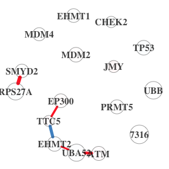

```r
set.seed(0) # Reset seed to use same layout as previous plot.
plot(results[[1]], alpha = 0.05, only_dc = TRUE, require_dc_genes = TRUE)
```

```r
summarize_edges(results[[1]], alpha = 0.05, require_dc_genes = TRUE)
```

```
## # A tibble: 5 × 6
##   pathway                                 edges dc_score p_value      nw1    nw2
##   <chr>                                   <chr>    <dbl>   <dbl>    <dbl>  <dbl>
## 1 Regulation of TP53 Activity through Me… ATM …   0.0303  0.0198 -0.0660  -0.240
## 2 Regulation of TP53 Activity through Me… EHMT…   0.0711  0.0297 -0.166    0.101
## 3 Regulation of TP53 Activity through Me… EHMT…   0.0305  0.0495  0.00952  0.184
## 4 Regulation of TP53 Activity through Me… EP30…   0.0215  0.0297  0.0431   0.190
## 5 Regulation of TP53 Activity through Me… RPS2…   0.0461  0.0297 -0.0182   0.197
```

## 4.4 Visualizing the shared edges

In many cases it may be useful to determine which gene-gene associations are *shared* across both groups in addition to those that are different. However, the utility of visualizing the network with both shared and differential edges is dependent on the association measure used. In this example, we used partial correlations; while this is a conditional measure that takes into account the expression of all the genes in the pathway, the specific estimator used will result in many nonzero estimates for the gene-gene associations. So, as we see in plot generated by the following code, the network is full of non-differentially connected edges.

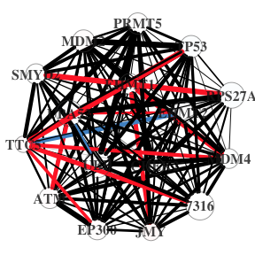

```r
set.seed(0) # Reset seed to use same layout as previous plot.
plot(results[[1]], alpha = 0.05)
```

**Note:** This type of visualization will provide more useful insights when a sparse estimator is used for the gene-gene associations (for example, using `run_aracne` as the network inference method, as shown in the next section).

## 4.5 Using other network inference methods

The default network inference method is `run_pcor`, which uses partial correlations to estimate the gene association network in the two groups. This is changed by setting the `network_inference` argument in `dnapath()`. For example:

```r
# Run the differntial network analysis using ARACNE.
results <- dnapath(x = meso$gene_expression,
                   pathway_list = p53_pathways,
                   groups = meso$groups,
                   network_inference = run_aracne)
```

**Note:** This code is not run here because it requires the `minet` package that is available on Bioconductor.

All of the summary and plotting functions behave the same as before regardless of the network inference method used. Note however, if the chosen method produces a dense network (such as `run_corr`), then the visualization may become more cluttered. In addition, some methods are more computationally intensive (such as `run_genie3`), and the differential network analysis will become more time consuming. To help counter this, the number of permutations performed for the significance testing can be lowered (the default is `n_perm = 100`). For example:

```r
# Run the differntial network analysis using GENIE3 with 20 permutations.
results <- dnapath(x = meso$gene_expression,
                   pathway_list = p53_pathways,
                   group_labels = meso$groups,
                   network_inference = run_genie3,
                   n_perm = 20)
```

Alternatively, there may be tuning parameters in the network inference method that can speed up computation. For example, in `run_genie3`, the `nTrees` argument might be lowered to trade-off performance for computation time. This parameter can be adjusted using the additional `...` argument of `dnapath`.

```r
# Run the differntial network analysis using GENIE3 with 20 permutations.
results <- dnapath(x = meso$gene_expression,
                   pathway_list = p53_pathways,
                   group_labels = meso$groups,
                   network_inference = run_genie3,
                   nTrees = 10)
```

# 5 Summary

In this brief introduction to the `dnapath` package, we have reviewed the basic steps for conducting the differential network analysis and for summarizing the results with tables and plots. The examples here used the Mesothelioma dataset that accompanies the package, but we reiterate that the package is not limited to analyzing *cancer* datasets.